# **Redes Neuronales Convolucionales con VGG16**

```python
import zipfile
```

Extraccion del dataset ya Preparado

```python
#!unrar x /content/AugmentedAlzheimerDataset.rar
with zipfile.ZipFile('processed_dataset_clahe.zip', 'r') as zip_ref:
  zip_ref.extractall()
  zip_ref.close()
    # Perform operations on the ZIP file
```

```python
import tensorflow as tf

print("GPUs disponibles:", tf.config.list_physical_devices('GPU'))
```

```
GPUs disponibles: [PhysicalDevice(name='/physical_device:GPU:0', device_type='GPU')]
```

```python
#!pip install keras-tuner
```

```python
import pandas as pd
import numpy as np
import keras
import warnings
warnings.filterwarnings(action="ignore")
import matplotlib.pyplot as plt
%matplotlib inline
import seaborn as sns

from keras.models import Sequential
from keras.layers import Dense, Dropout, Flatten
from keras.layers import Conv2D, MaxPooling2D
from keras import backend as K

from sklearn.preprocessing import StandardScaler
from sklearn.model_selection import train_test_split
from sklearn.metrics import classification_report
import tensorflow as tf
from tensorflow import keras
from tensorflow.keras.models import Sequential
from tensorflow.keras.layers import Conv2D, MaxPooling2D, Flatten, Dense, BatchNormalization, MaxPool2D
from tensorflow.keras.applications.vgg19 import VGG19
from tensorflow.keras.optimizers import Adam
from tensorflow.keras.losses import SparseCategoricalCrossentropy
from tensorflow.keras.preprocessing.image import ImageDataGenerator
from tensorflow.keras.callbacks import TensorBoard,EarlyStopping

import random
import matplotlib.pyplot as plt
import numpy as np
import tensorflow as tf
from tensorflow.keras import Sequential
from tensorflow.keras.layers import Conv2D, Dense, MaxPooling2D, Flatten, Dropout, BatchNormalization, GlobalAveragePooling2D
from tensorflow.keras.optimizers import Adam
from tensorflow.keras.applications import VGG16
from tensorflow.keras.callbacks import ReduceLROnPlateau
from dataclasses import dataclass



import sklearn.metrics as metrics
from keras.callbacks import LearningRateScheduler
from tensorflow.keras.preprocessing.image import ImageDataGenerator
annealer = LearningRateScheduler(lambda x: 1e-3 * 0.95 ** x, verbose=0)


print('Módulos importados')
```

```
Módulos importados
```

## Definicion de los paths de cada clase

```python
MildDemented_dir = r'processed_dataset_clahe/MildDemented'
ModerateDemented_dir = r'processed_dataset_clahe/ModerateDemented'
NonDemented_dir = r'processed_dataset_clahe/NonDemented'
VeryMildDemented_dir = r'processed_dataset_clahe/VeryMildDemented'

NUM_CLASSES = 4
BATCH_SIZE = 32
```

```python
import os
import pandas as pd


filepaths = []
labels = []
dict_list = [MildDemented_dir, ModerateDemented_dir, NonDemented_dir, VeryMildDemented_dir]
class_labels = ['Mild Demented', 'Moderate Demented', 'Non Demented', 'Very MildDemented']

for i, j in enumerate(dict_list):
    flist = os.listdir(j)
    for f in flist:
        fpath = os.path.join(j, f)
        filepaths.append(fpath)
        labels.append(class_labels[i])

Fseries = pd.Series(filepaths, name="filepaths")
Lseries = pd.Series(labels, name="labels")
Alzheimer_data = pd.concat([Fseries, Lseries], axis=1)
Alzheimer_df = pd.DataFrame(Alzheimer_data)
#print(Alzheimer_df.head())
print(Alzheimer_df["labels"].value_counts())
```

```
labels
Non Demented        12800
Very MildDemented   11200
Mild Demented       9856
Moderate Demented   6528
Name: count, dtype: int64
```

```python
train_images, test_images = train_test_split(Alzheimer_df, test_size=0.3, random_state=42)
train_set, val_set = train_test_split(Alzheimer_df, test_size=0.2, random_state=42)


image_gen = ImageDataGenerator(preprocessing_function= tf.keras.applications.mobilenet_v2.preprocess_input)
train = image_gen.flow_from_dataframe(dataframe= train_set,x_col="filepaths",y_col="labels",
                                      target_size=(224,224),
                                      class_mode="categorical",
                                      batch_size=32,
                                      shuffle=False
                                     )
test = image_gen.flow_from_dataframe(dataframe= test_images,x_col="filepaths", y_col="labels",
                                     target_size=(224,224),
                                     class_mode="categorical",
                                     batch_size=32,
                                     shuffle= False
                                    )
val = image_gen.flow_from_dataframe(dataframe= val_set,x_col="filepaths", y_col="labels",
                                    target_size=(224,224),
                                    class_mode="categorical",
                                    batch_size=32,
                                    shuffle=False
                                   )
```

```
Found 31027 validated image filenames belonging to 4 classes.
Found 11636 validated image filenames belonging to 4 classes.
Found 7757 validated image filenames belonging to 4 classes.
```

Definimos el modelo con VGG16 para entrenar, donde usaremos 512 y 256 neuronas con una activasion "Relu" de entrada, y una Softmax para la salida

Este entrenamiento tambien juega bastante el learning_rate para controlar la velocidad a la que se entrenara el modelo y asi evitar que tanto se salte pasos importantes, como tambien se sobreentrene el modelo

```python
base_model = VGG16(weights='imagenet', include_top=False, input_shape=(224, 224, 3))

model = keras.models.Sequential([
    base_model,
    GlobalAveragePooling2D(),
    BatchNormalization(),

    #Dense(1024, activation='relu'),
    #Dropout(0.3),
    #BatchNormalization(),
    Dense(512, activation='relu'),
    Dropout(0.3),
    BatchNormalization(),
    Dense(256, activation='relu'),
    Dropout(0.3),
    Dense(NUM_CLASSES, activation='softmax')
])

model.compile(
    loss='categorical_crossentropy',
    optimizer=tf.optimizers.SGD(learning_rate=0.0001),
    metrics=['accuracy']
)

model.summary()
```

```
Downloading data from https://storage.googleapis.com/tensorflow/keras-applications/vgg16/vgg16_weights_tf_dim_ordering_tf_kernels_notop.h5
58889256/58889256 ━━━━━━━━━━━━━━━━━━━━ 2s 0us/step
```

```
Model: "sequential"
```

```
┏━━━━━━━━━━━━━━━━━━━━━━━━━━━━━━━━━━━━━━┳━━━━━━━━━━━━━━━━━━━━━━━━━━━━━┳━━━━━━━━━━━━━━━━━┓
┃ Layer (type)                         ┃ Output Shape                ┃         Param # ┃
┡━━━━━━━━━━━━━━━━━━━━━━━━━━━━━━━━━━━━━━╇━━━━━━━━━━━━━━━━━━━━━━━━━━━━━╇━━━━━━━━━━━━━━━━━┩
│ vgg16 (Functional)                   │ (None, 7, 7, 512)           │      14,714,688 │
├──────────────────────────────────────┼─────────────────────────────┼─────────────────┤
│ global_average_pooling2d             │ (None, 512)                 │               0 │
│ (GlobalAveragePooling2D)             │                             │                 │
├──────────────────────────────────────┼─────────────────────────────┼─────────────────┤
│ batch_normalization                  │ (None, 512)                 │           2,048 │
│ (BatchNormalization)                 │                             │                 │
├──────────────────────────────────────┼─────────────────────────────┼─────────────────┤
│ dense (Dense)                        │ (None, 512)                 │         262,656 │
├──────────────────────────────────────┼─────────────────────────────┼─────────────────┤
│ dropout (Dropout)                    │ (None, 512)                 │               0 │
├──────────────────────────────────────┼─────────────────────────────┼─────────────────┤
│ batch_normalization_1                │ (None, 512)                 │           2,048 │
│ (BatchNormalization)                 │                             │                 │
├──────────────────────────────────────┼─────────────────────────────┼─────────────────┤
│ dense_1 (Dense)                      │ (None, 256)                 │         131,328 │
├──────────────────────────────────────┼─────────────────────────────┼─────────────────┤
│ dropout_1 (Dropout)                  │ (None, 256)                 │               0 │
├──────────────────────────────────────┼─────────────────────────────┼─────────────────┤
│ dense_2 (Dense)                      │ (None, 4)                   │           1,028 │
└──────────────────────────────────────┴─────────────────────────────┴─────────────────┘
```

```
 Total params: 15,113,796 (57.65 MB)
```

```
 Trainable params: 15,111,748 (57.65 MB)
```

```
 Non-trainable params: 2,048 (8.00 KB)
```

Definimos una clase de Training de datos para el modelo

```python
@dataclass(frozen=True)
class TrainingConfig:
    EPOCHS: int = 20
    BATCH_SIZE: int = BATCH_SIZE
    LEARNING_RATE: float = 0.0001
```

```python
optimizer = Adam(learning_rate=TrainingConfig.LEARNING_RATE)
model.compile(optimizer=optimizer, loss='categorical_crossentropy', metrics=['accuracy'])
```

Con `ReduceLROnPlateau` permite un ajuste dinamico del learning_rate para evitar:

- Estancamiento durante el entrenamiento
- Facilitar la convergencia en etapas avanzadas del entrenamiento
- Prevenir el uso de un learning rate innecesariamente alto que pueda causar inestabilidad o sobrepasar los mínimos.

```python
lr_scheduler = ReduceLROnPlateau(monitor='val_loss', factor=0.5, patience=3, min_lr=1e-6)
```

```python
history = model.fit(
    train,
    validation_data=val,
    epochs=TrainingConfig.EPOCHS,
    callbacks=[lr_scheduler],
    verbose=1
)
```

```
970/970 ━━━━━━━━━━━━━━━━━━━━ 523s 532ms/step - accuracy: 0.5332 - loss: 1.1183 - val_accuracy: 0.3001 - val_loss: 5.4668 - learning_rate: 1.0000e-04
970/970 ━━━━━━━━━━━━━━━━━━━━ 509s 525ms/step - accuracy: 0.8966 - loss: 0.2712 - val_accuracy: 0.5863 - val_loss: 1.4484 - learning_rate: 1.0000e-04
970/970 ━━━━━━━━━━━━━━━━━━━━ 507s 523ms/step - accuracy: 0.9671 - loss: 0.0953 - val_accuracy: 0.8657 - val_loss: 0.4125 - learning_rate: 1.0000e-04
970/970 ━━━━━━━━━━━━━━━━━━━━ 506s 522ms/step - accuracy: 0.9794 - loss: 0.0570 - val_accuracy: 0.4359 - val_loss: 4.3331 - learning_rate: 1.0000e-04
970/970 ━━━━━━━━━━━━━━━━━━━━ 505s 521ms/step - accuracy: 0.9845 - loss: 0.0463 - val_accuracy: 0.6885 - val_loss: 2.3471 - learning_rate: 1.0000e-04
970/970 ━━━━━━━━━━━━━━━━━━━━ 503s 519ms/step - accuracy: 0.9857 - loss: 0.0438 - val_accuracy: 0.7703 - val_loss: 0.8936 - learning_rate: 1.0000e-04
970/970 ━━━━━━━━━━━━━━━━━━━━ 504s 519ms/step - accuracy: 0.9978 - loss: 0.0071 - val_accuracy: 0.9919 - val_loss: 0.0250 - learning_rate: 5.0000e-05
970/970 ━━━━━━━━━━━━━━━━━━━━ 504s 519ms/step - accuracy: 0.9981 - loss: 0.0055 - val_accuracy: 0.4905 - val_loss: 3.9362 - learning_rate: 5.0000e-05
970/970 ━━━━━━━━━━━━━━━━━━━━ 503s 519ms/step - accuracy: 0.9955 - loss: 0.0127 - val_accuracy: 0.9818 - val_loss: 0.0570 - learning_rate: 5.0000e-05
970/970 ━━━━━━━━━━━━━━━━━━━━ 502s 518ms/step - accuracy: 0.9975 - loss: 0.0077 - val_accuracy: 0.9254 - val_loss: 0.2383 - learning_rate: 5.0000e-05
970/970 ━━━━━━━━━━━━━━━━━━━━ 503s 518ms/step - accuracy: 0.9990 - loss: 0.0037 - val_accuracy: 0.9982 - val_loss: 0.0060 - learning_rate: 2.5000e-05
970/970 ━━━━━━━━━━━━━━━━━━━━ 502s 518ms/step - accuracy: 0.9999 - loss: 4.8138e-04 - val_accuracy: 0.9988 - val_loss: 0.0037 - learning_rate: 2.5000e-05
970/970 ━━━━━━━━━━━━━━━━━━━━ 502s 518ms/step - accuracy: 1.0000 - loss: 1.2939e-04 - val_accuracy: 0.9988 - val_loss: 0.0039 - learning_rate: 2.5000e-05
970/970 ━━━━━━━━━━━━━━━━━━━━ 502s 517ms/step - accuracy: 0.9999 - loss: 3.1742e-04 - val_accuracy: 0.9394 - val_loss: 0.2821 - learning_rate: 2.5000e-05
970/970 ━━━━━━━━━━━━━━━━━━━━ 503s 518ms/step - accuracy: 0.9975 - loss: 0.0073 - val_accuracy: 0.9972 - val_loss: 0.0103 - learning_rate: 2.5000e-05
970/970 ━━━━━━━━━━━━━━━━━━━━ 504s 519ms/step - accuracy: 0.9998 - loss: 5.7967e-04 - val_accuracy: 0.9983 - val_loss: 0.0065 - learning_rate: 1.2500e-05
970/970 ━━━━━━━━━━━━━━━━━━━━ 503s 518ms/step - accuracy: 1.0000 - loss: 1.3797e-04 - val_accuracy: 0.9985 - val_loss: 0.0055 - learning_rate: 1.2500e-05
970/970 ━━━━━━━━━━━━━━━━━━━━ 502s 518ms/step - accuracy: 1.0000 - loss: 8.4089e-05 - val_accuracy: 0.9987 - val_loss: 0.0051 - learning_rate: 1.2500e-05
970/970 ━━━━━━━━━━━━━━━━━━━━ 503s 518ms/step - accuracy: 1.0000 - loss: 6.6968e-05 - val_accuracy: 0.9986 - val_loss: 0.0048 - learning_rate: 6.2500e-06
970/970 ━━━━━━━━━━━━━━━━━━━━ 502s 518ms/step - accuracy: 1.0000 - loss: 3.7258e-05 - val_accuracy: 0.9988 - val_loss: 0.0047 - learning_rate: 6.2500e-06
```

```python
model.evaluate(test, verbose=1)
```

```
364/364 ━━━━━━━━━━━━━━━━━━━━ 47s 128ms/step - accuracy: 0.9986 - loss: 0.0047
```

```
[0.0031498419120907784, 0.9992265105247498]
```

Guardamos la Red Neuronal que hemos entrenado

```python
model.save("redCNN.h5")
```

```
WARNING:absl:You are saving your model as an HDF5 file via `model.save()` or `keras.saving.save_model(model)`. This file format is considered legacy. We recommend using instead the native Keras format, e.g. `model.save('my_model.keras')` or `keras.saving.save_model(model, 'my_model.keras')`.
```

```python
pred = model.predict(test)
pred = np.argmax(pred, axis=1) #predice la clase con mayor probabilidad

labels = (train.class_indices)
labels = dict((v,k) for k,v in labels.items())
pred2 = [labels[k] for k in pred]
```

```
364/364 ━━━━━━━━━━━━━━━━━━━━ 46s 124ms/step
```

Tenemos el modelo entrenado y acontinuacion mostraremos el entrenamiento y perdida que tuvo el modelo

[figure not shown]

```python
plt.plot(history.history['accuracy'])
plt.plot(history.history['val_accuracy'])
plt.title('model accuracy')
plt.ylabel('accuracy')
plt.xlabel('epoch')
plt.legend(['train', 'val'], loc='upper left')
plt.show()
```

Esta grafica mostrara como protagonista la perdida que tuvo el modelo durante el entrenamiento

[figure not shown]

```python
plt.plot(history.history['loss'])
plt.plot(history.history['val_loss'])
plt.title('model loss')
plt.ylabel('loss')
plt.xlabel('epoch')
plt.legend(['train', 'val'], loc='upper left')
plt.show()
```

### Metricas del modelo entrenado

Las metricas obtenidas por el modelo si demuestran una mejora significativa, siendo 1.0 lo mejor en Precision, Recall, F1-score y Accuracy

```python
from sklearn.metrics import confusion_matrix, accuracy_score

y_test = test_images.labels # establece la salida esperada
print(classification_report(y_test, pred2))
print("Accuracy of the Model:","{:.1f}%".format(accuracy_score(y_test, pred2)*100))
```

```
                   precision    recall  f1-score   support

    Mild Demented       1.00      1.00      1.00      3013
Moderate Demented       1.00      1.00      1.00      1929
     Non Demented       1.00      1.00      1.00      3324
Very MildDemented       1.00      1.00      1.00      3370

         accuracy                           1.00     11636
        macro avg       1.00      1.00      1.00     11636
     weighted avg       1.00      1.00      1.00     11636

Accuracy of the Model: 99.9%
```

### Matriz de confusión:

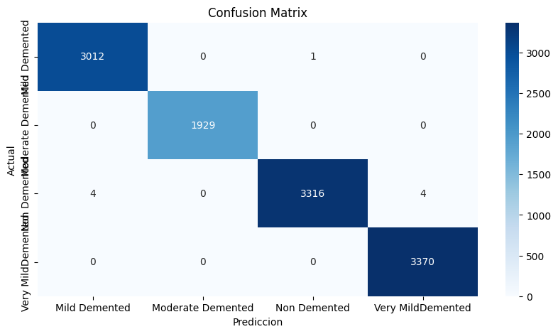

```python
import matplotlib.pyplot as plt
import seaborn as sns
from sklearn.metrics import confusion_matrix

# Define the class labels
class_labels = ['Mild Demented', 'Moderate Demented', 'Non Demented', 'Very MildDemented']

# Calculate the confusion matrix
cm = confusion_matrix(y_test, pred2)

# Create a figure and plot the confusion matrix as a heatmap
plt.figure(figsize=(10, 5))
sns.heatmap(cm, annot=True, fmt='g', vmin=0, cmap='Blues')

# Set tick labels and axis labels
plt.xticks(ticks=[0.5, 1.5, 2.5, 3.5], labels=class_labels)
plt.yticks(ticks=[0.5, 1.5, 2.5, 3.5], labels=class_labels)
plt.xlabel("Prediccion")
plt.ylabel("Actual")

# Set the title
plt.title("Confusion Matrix")

# Show the plot
plt.show()
```

```python
# Load the saved model
from tensorflow.keras.models import load_model
import numpy as np
from tensorflow.keras.preprocessing import image
from tf_explain.core.integrated_gradients import IntegratedGradients


loaded_model = load_model("redCNN.h5")
```

```
WARNING:absl:Compiled the loaded model, but the compiled metrics have yet to be built. `model.compile_metrics` will be empty until you train or evaluate the model.
```

A continuacion se mostraran la prediccion de nuevos ejemplos con el modelo ya entrenado, incluyendo una muestra de Gradientes Integrados, donde podremos observar cuales fueron los pixeles que mas peso tuvieron durante la prediccion

```
1/1 ━━━━━━━━━━━━━━━━━━━━ 0s 466ms/step
```

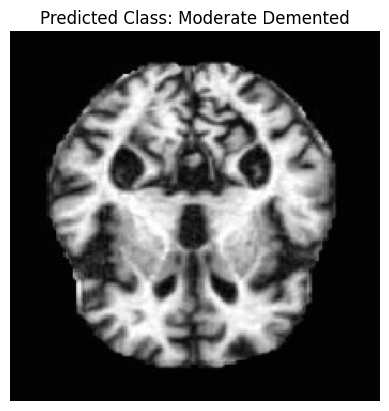

```python
import numpy as np
from tensorflow.keras.preprocessing import image
import matplotlib.pyplot as plt

#Definimos los nombres de las clases
class_names = ['Mild Demented', 'Moderate Demented', 'Non-Demented', 'Very Mild Demented']  # Adjust to match your class order


image_path = 'processed_dataset_clahe/ModerateDemented/001ef5a6-893b-4ede-9cf8-60b7fb94a541.jpg'   # Replace with your image path

# Load and preprocess the image
img = image.load_img(image_path, target_size=(224, 224))
img_array = image.img_to_array(img)
img_array = np.expand_dims(img_array, axis=0)  # Add batch dimension
img_array = img_array / 255.0  # Normalize as done during training

# Predict the class
predictions = loaded_model.predict(img_array)
predicted_class = np.argmax(predictions, axis=1)[0]

# Get the class name using the index
predicted_class_name = class_names[predicted_class]

target_label = predicted_class

# Display the image and predicted class name
plt.imshow(img)
plt.axis('off')
plt.title(f"Predicted Class: {predicted_class_name}")
plt.show()
```

```
ndarray (224, 224)
```

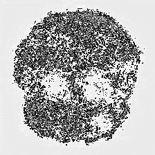

```
array([[234, 237, 238, ..., 235, 234, 234],
       [235, 238, 238, ..., 240, 237, 234],
       [234, 235, 237, ..., 238, 236, 234],
       ...,
       [235, 234, 236, ..., 234, 234, 234],
       [234, 234, 234, ..., 234, 234, 234],
       [235, 236, 236, ..., 235, 235, 235]], dtype=uint8)
```

```python
explainer = IntegratedGradients()
explanations = explainer.explain(
    validation_data=(img_array, target_label),  # Pasar la imagen y la clase objetivo
    model=model,
    class_index=target_label  # Especificar la clase objetivo
)
explanations
```

```
1/1 ━━━━━━━━━━━━━━━━━━━━ 0s 19ms/step
```

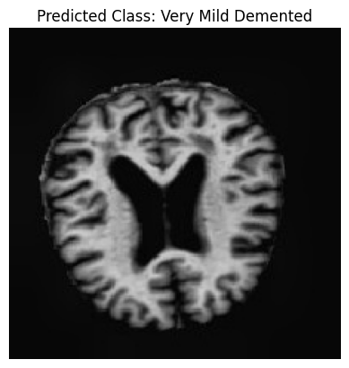

```python
import numpy as np
from tensorflow.keras.preprocessing import image
import matplotlib.pyplot as plt


# Path to the new image
image_path = 'processed_dataset_clahe/VeryMildDemented/71902420-7ec6-44e3-b9de-0b899ef068ea.jpg'   # Replace with your image path

# Load and preprocess the image
img = image.load_img(image_path, target_size=(224, 224))
img_array = image.img_to_array(img)
img_array = np.expand_dims(img_array, axis=0)  # Add batch dimension
img_array = img_array / 255.0  # Normalize as done during training

# Predict the class
predictions = loaded_model.predict(img_array)
predicted_class = np.argmax(predictions, axis=1)[0]

# Get the class name using the index
predicted_class_name = class_names[predicted_class]
target_label = predicted_class

# Display the image and predicted class name
plt.imshow(img)
plt.axis('off')
plt.title(f"Predicted Class: {predicted_class_name}")
plt.show()
```

```
ndarray (224, 224)
```

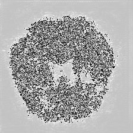

```
array([[196, 201, 195, ..., 195, 195, 195],
       [201, 211, 199, ..., 196, 195, 195],
       [202, 210, 199, ..., 196, 196, 195],
       ...,
       [199, 200, 200, ..., 195, 195, 195],
       [199, 202, 195, ..., 197, 195, 194],
       [196, 196, 197, ..., 195, 194, 195]], dtype=uint8)
```

```python
explainer = IntegratedGradients()
explanations = explainer.explain(
    validation_data=(img_array, target_label),  # Pasar la imagen y la clase objetivo
    model=model,
    class_index=target_label  # Especificar la clase objetivo
)
explanations
```

```
1/1 ━━━━━━━━━━━━━━━━━━━━ 0s 17ms/step
```

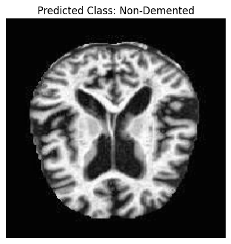

```python
import numpy as np
from tensorflow.keras.preprocessing import image
import matplotlib.pyplot as plt

# Path to the new image
image_path = 'processed_dataset_clahe/NonDemented/nonDem1928.jpg'   # Replace with your image path

# Load and preprocess the image
img = image.load_img(image_path, target_size=(224, 224))
img_array = image.img_to_array(img)
img_array = np.expand_dims(img_array, axis=0)  # Add batch dimension
img_array = img_array / 255.0  # Normalize as done during training

# Predict the class
predictions = loaded_model.predict(img_array)
predicted_class = np.argmax(predictions, axis=1)[0]

# Get the class name using the index
predicted_class_name = class_names[predicted_class]
target_label = predicted_class

# Display the image and predicted class name
plt.imshow(img)
plt.axis('off')
plt.title(f"Predicted Class: {predicted_class_name}")
plt.show()
```

```
ndarray (224, 224)
```

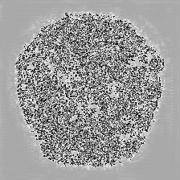

```
array([[168, 169, 169, ..., 171, 171, 169],
       [169, 169, 176, ..., 174, 171, 169],
       [170, 169, 176, ..., 172, 177, 170],
       ...,
       [170, 171, 172, ..., 169, 169, 168],
       [169, 170, 171, ..., 169, 169, 169],
       [168, 168, 171, ..., 168, 169, 169]], dtype=uint8)
```

```python
explainer = IntegratedGradients()
explanations = explainer.explain(
    validation_data=(img_array, target_label),  # Pasar la imagen y la clase objetivo
    model=model,
    class_index=target_label  # Especificar la clase objetivo
)
explanations
```

```
1/1 ━━━━━━━━━━━━━━━━━━━━ 0s 17ms/step
```

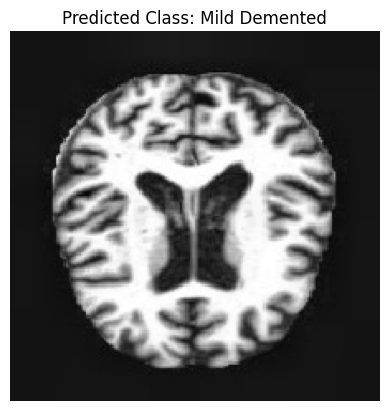

```python
import numpy as np
from tensorflow.keras.preprocessing import image
import matplotlib.pyplot as plt

image_path = 'processed_dataset_clahe/MildDemented/7eef101f-f654-4274-86f3-a506a505a34f.jpg'   # Replace with your image path

# Load and preprocess the image
img = image.load_img(image_path, target_size=(224, 224))
img_array = image.img_to_array(img)
img_array = np.expand_dims(img_array, axis=0)  # Add batch dimension
img_array = img_array / 255.0  # Normalize as done during training

# Predict the class
predictions = loaded_model.predict(img_array)
predicted_class = np.argmax(predictions, axis=1)[0]

# Get the class name using the index
predicted_class_name = class_names[predicted_class]
target_label = predicted_class

# Display the image and predicted class name
plt.imshow(img)
plt.axis('off')
plt.title(f"Predicted Class: {predicted_class_name}")
plt.show()
```

```
ndarray (224, 224)
```

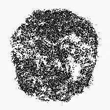

```
array([[247, 248, 249, ..., 247, 247, 247],
       [248, 249, 249, ..., 249, 248, 247],
       [247, 247, 248, ..., 249, 249, 247],
       ...,
       [247, 248, 248, ..., 247, 247, 247],
       [247, 247, 247, ..., 248, 247, 247],
       [248, 248, 247, ..., 247, 248, 248]], dtype=uint8)
```

```python
explainer = IntegratedGradients()
explanations = explainer.explain(
    validation_data=(img_array, target_label),  # Pasar la imagen y la clase objetivo
    model=model,
    class_index=target_label  # Especificar la clase objetivo
)
explanations
```

Aqui realizamos algunas predicciones con un Gradiente Integrado ya terminado el entrenamiento del modelo. Estos Gradientes Integrados nos serviran bastante para explicar las predicciones hechas por el modelo, y eso lo veremos en el siguiente cuaderno: `3. Prediccion y explicacion de nuevos Samples.ipynb`.